# Lab 01 - Introduction to Matlab

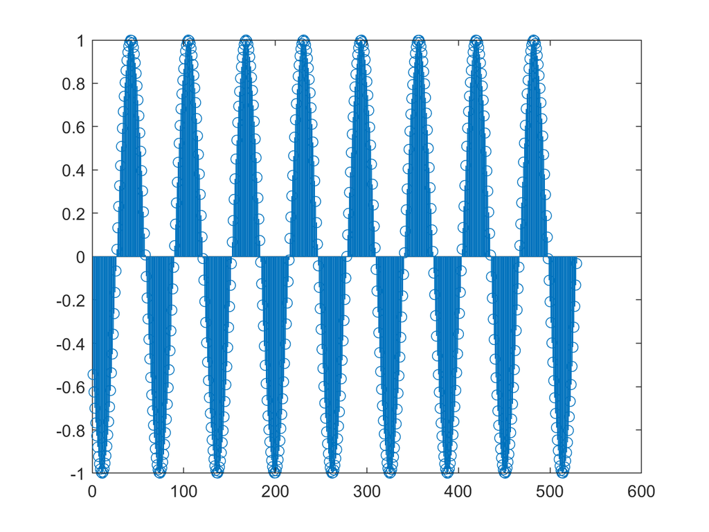

```matlab
stem(X)       % Use stem() to display values with vertical sticks, like a discrete signal
```

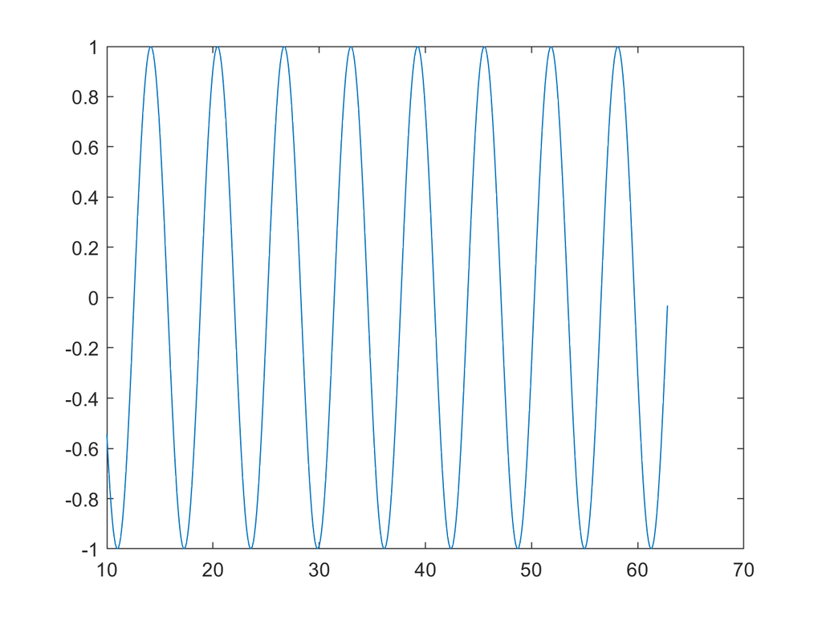

```matlab
plot(A, X)    % Like plot(X), but puts values in A on the Ox axis
```

### 2.4 Keywords

If-then

```matlab
a = sqrt(123)
```

a = 11.0905

```matlab
if (a >= 10)
    b = 15;
end

a = sqrt(123)
```

a = 11.0905

```matlab
if (a >= 10)
    b = 15;
else
    c = 'ala bala portocala';   % c is a string
end
```

While:

```matlab
a = 5;
i = 0
```

i = 0

```matlab
while (a < 20)
    a = a + 0.2;
    i = i + 1;
end
fprintf('It took %d loops for a to exceed 20', i);
```

It took 76 loops for a to exceed 20

## 3. Exercises

1. Define two variables $a=5$ and $b=0.3$ and compute $a+b$, $\frac{a}{b}$, $a^b$, $e^{a + ln(b)}$, $sin(a) + cos (b + \frac{\pi}{2})$

2. Define a vector A with 10 zeros, a matrix B of size $4 \times 6$ with all elements equal to 1, and a vector C with odd numbers from 1 la 21 (both included).

- Change the third element of A to 5
- Change element B(2,4) to 7
- Square all the elements of C, and save the result as a new vector D.
- Compute E = 4C - 50.
- Compare element-wise the vectors C and E. How many elements of C are larger than the corresponding elements from E? (use functions to calculate this, don't just count it yourselves)
- Apply sin() to all the elements of D

3. Define a vector t with 1000 elements uniformly spaced between 0 and 10. Compute and plot $\cos(2 \pi f t)$, where f = 0.5.

4. Plot the signal $\sin(2 \pi f t + \frac{\pi}{4})$, with f = 0.2, for a duration of 3 periods.